# R Markdown Example

January 16, 2019

# Hello!

Welcome to the R Markdown example document.

## Getting started

To work with R Markdown, if necessary:

- Install [R](http://www.r-project.org/)
- Install the latest version of [RStudio](http://rstudio.org/download/)
- Install the latest version of the `knitr` package: `install.packages("knitr")`

If you’re looking for a quick reference to R Markdown formatting, I strongly suggest you check out **[this helpful cheat sheet](https://www.rstudio.com/wp-content/uploads/2016/03/rmarkdown-cheatsheet-2.0.pdf)**!

# R Markdown formatting

In R Markdown, you can type normally as you would in a simple text document. This text can be interspersed with R code in what are called **chunks**. The ability to combine text and R code means that you can develop papers, manuscripts, presentations, and web pages (and more!) within a single document.

In order to see the code used to generate the formatting you’ll see in the output document, we recommend you open to R Markdown (.Rmd) file as well as the final outputted PDF.

## Text formatting

You can *italicize* text by placing it inside of a single set of *asterisks* (`*`) or *underscores* (`_`).

You can **bold** text by placing it inside of a double set of **asterisks** (`**`) or **underscores**(`__`).

Headers are created by starting a line with a specific number of pound or hash signs (`#`) that corresponds with the level of your header. For example:

# First-level header

## Second-level header

### Third-level header

#### Fourth-level header

##### Fifth-level header

## Lists

An unordered list (with bullet points) can be created by typing an asterisk and space (`*`) at the beginning of each line. Second-level sub-bullets can be created by typing tab *twice* and then typing a hyphen and a space (`-`) at the beginning of each line. (I think on some computers sub-bullets may work if you type tab once, but it doesn’t on my Mac!)

- Bullet 1
  - Sub-bullet 1
  - Sub-bullet 2
- Bullet 2
- Bullet 3

Please note: You’ll need to *leave a blank line in your .Rmd file before the first bullet* or it won’t output properly.

An ordered list (with numbers) can be created by typing a number, period, and space (e.g., `1.`) at the beginning of each line. Second-level sub-bullets can be created by typing tab *twice* and then typing “i”, a right parenthesis, and a space (`i)`) at the beginning of each line. (With each new line, you’ll increase your “i”s as this is written in lowercase Roman numerals.)

1. Number 1
   1. Sub-bullet 1
   2. Sub-bullet 2
2. Number 2
3. Number 3

## Equations

You can add equations to your R Markdown file by including them either between single dollar signs (for inline equations within your text) or double dollar signs (for a separate equation section below your text–often used to highlight formulas in papers). This is based on something called LaTeX notation.

Here is an example of an inline equation: $y_i = \alpha + \beta x_i + e_i$.

Here is a displayed formula:

$$\frac{1}{1+\exp(-x)}$$

## Hyperlinks

You can add a hyperlink by typing the text you’d like to link in brackets followed by the URL in parentheses *with no space between them*. [Here is an example](http://psychology.columbia.edu).

## Images

The code to include an image is similar to that for a hyperlink. You’ll type an exlamation point, followed by the image caption in brackets, followed by the image location (either a URL or a path to the image’s location on your computer) with no spaces between them. The image here is a bit large, so you’ll see that RMarkdown pushed it to the next page in the knitted PDF document.

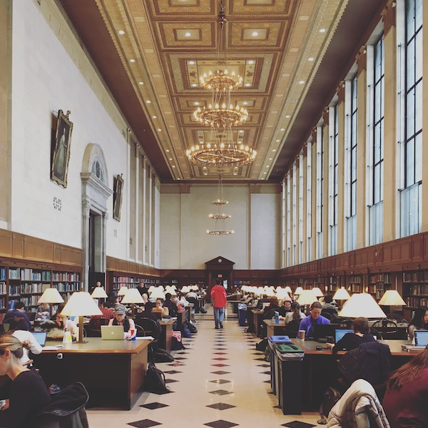

Butler Library

## Quotes

Quotes can be included by typing a greater-than sign and space at the beginning of each line (`>`).

> To be, or not to be, that is the question: Whether ’tis nobler in the mind to suffer The slings and arrows of outrageous fortune…

## Tables

Basic tables can be included using the following notation:

| A | B | C |
| --- | --- | --- |
| 1 | Male | Blue |
| 2 | Female | Pink |

You can also include tables within code chunks, which will be illustrated in the next section.

# Code

## Code chunks

Most of the time, you’ll use code chunks within R Markdown to run your code. Here is an example code chunk. (I’ve also created some dummy data here we’ll use to demonstrate functions in subsequent code chunks.)

````
```r
x <- c(1, 2, 4, 4, 5, 5, 5, 7, 9, 9)
y <- 1:10
df <- data.frame(x, y)
x
```

```
##  [1] 1 2 4 4 5 5 5 7 9 9
```
````

## Inline code

Inline code can be included by placing your code in and starting it with `r` and a space. (If you’re viewing this in the PDF, see the .Rmd file for the code.) Inline code can be a really helpful way to pull out a datapoint and include it in your text. For example, here is the second value in our vector `x` : 2.

## Tables (from code chunks)

You can create a table of a dataframe by placing the dataframe name within the `kable()` function.

```r
kable(df)
```

| x | y |
| --- | --- |
| 1 | 1 |
| 2 | 2 |
| 4 | 3 |
| 4 | 4 |
| 5 | 5 |
| 5 | 6 |
| 5 | 7 |
| 7 | 8 |
| 9 | 9 |
| 9 | 10 |

## Plots

Images generated by `knitr` are saved in a figures folder.

### Simple plots

Here is a basic plot using base-R graphics.

[output not shown]

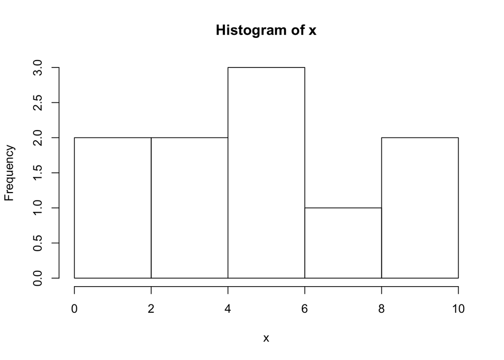

```r
hist(x)
```

### `ggplot2` plots

`ggplot2` plots work as well:

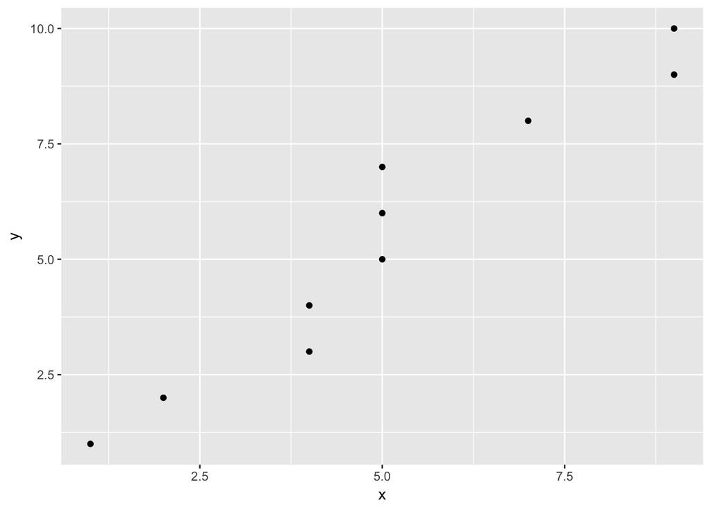

```r
ggplot(data = df, aes(x = x, y = y)) +
  geom_point()
```

## Code chunk options

There are a wide range of code chunk options, which you can find listed in **[this helpful cheat sheet](https://www.rstudio.com/wp-content/uploads/2016/03/rmarkdown-cheatsheet-2.0.pdf)**. We highlight some of the most common here.

### `eval`: Evaluate the code in the chunk (or not)

You can tell R not to evaluate (i.e., run) the code in a particular chunk by inserting `eval = FALSE` at the beginning of your code chunk.

````
```r
# We included the eval = FALSE option at the beginning of this chunk
y <- 0
```


```r
# We can check here and see that the change in the previous chunk was not made to y
# because the code wasn't evaluated.
y
```

```
##  [1]  1  2  3  4  5  6  7  8  9 10
```
````

### `cache`: Save a copy of your analysis (or not)

You can cache the results of your analyses if the analyses take a long time to run. If you insert `cache = TRUE` at the beginning of your code chunk, the analysis will run in full the first time you knit the file; in future knits, the code will not be re-run.

If you want to re-run cached code chunks, just [delete the contents of the `cache` folder](http://stackoverflow.com/a/10629121/180892)

````
```r
for (i in 1:5000) {
    lm((i+1)~i)
}
```
````

### `echo`: Show vs. hide command input

The `echo = FALSE` code hides the code within the code chunk within your output file but still runs the code. `results = 'asis'` here formats the output to match your document format (i.e., *not* to look like code output in the Courier font).

Here are some points within our `y` vector

- The value of y[1] is 1
- The value of y[2] is 2
- The value of y[3] is 3

### `fig.width` and `fig.height`: Adjust your figure size

The following is an example of a smaller figure using `fig.width` and `fig.height` options.

[output not shown]

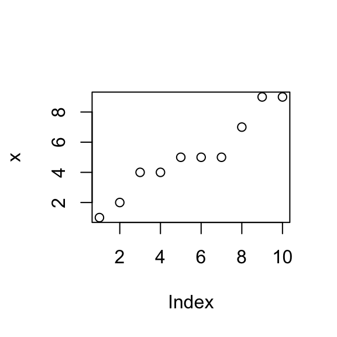

```r
plot(x)
```

# R Markdown file types

There are a wide range of files you can create using R Markdown, but the options you’ll probably use most commonly are a PDF, Word document, and HTML file. To change the output file type, change the `output:` line in your .Rmd header based on your desired file type:

- PDF: `pdf_document`
- Word: `word_document`
- HTML: `html_document`